# Midterm

## III. Predictive Models

Continue with the data from part I. Make sure you do not have any missing values in the data. Use the follows as the target and input variables:

*Target Variable*: Create the target variable taking value of

- `low` if the total charge of a patient (`tot`) is smaller than the median of the total charge, and
- `high` otherwise.

*Input Variables*:

- “age”,“sex”,“raceethn”,“provider”,“moa”,“mod”,“admtype”,“campus”, ‘los’

```r
head(df)
```

```
## # A tibble: 6 × 51
##     yod payfix pay_ub92   age sex    raceethn provider   moa   yoa   mod admtype
##   <dbl> <lgl>     <dbl> <dbl> <chr>  <chr>    <chr>    <dbl> <dbl> <dbl> <chr>
## 1     3 NA           NA    39 Female 1        7216         2     3     2 3
## 2     3 NA           NA    59 Female 1        7216         1     3     1 3
## 3     3 NA           NA    57 Male   1        7216         2     3     2 1
## 4     3 NA           NA    54 Female 1        7216         2     3     3 3
## 5     3 NA           NA    54 Female 1        7216         1     3     2 1
## 6     3 NA           NA    54 Female 1        7216         3     3     3 1
## # ℹ 40 more variables: asource <chr>, preopday <dbl>, los <dbl>, service <chr>,
## #   icu <chr>, ccu <chr>, dispub92 <chr>, payer <chr>, drg <dbl>, trandb <chr>,
## #   randbg <chr>, randbs <chr>, orr <chr>, anes <chr>, seq <chr>, lab <chr>,
## #   dtest <chr>, ther <chr>, blood <chr>, phar <chr>, other <chr>,
## #   patcon <chr>, bwght <lgl>, total <chr>, tot <dbl>, ecodub92 <chr>,
## #   b_wt <chr>, pt_state <chr>, diag_adm <chr>, ancilar <chr>, campus <dbl>,
## #   er_fee <chr>, er_chrg <chr>, er_mode <dbl>, obs_chrg <chr>, …
```

1. Use `filter` function to filter out rows where `raceethn==''` or `admtype==''`. Make sure all the categorical variables are factor, numeric variables are numeric. Set Training : Testing Split = 10 : 90

```r
setwd("C:/Users/student/Downloads")
df <- read_csv('421midterm.csv')
df$sex <- case_when(
  df$sex == 2 ~ 'Female',
  TRUE ~ 'Male')

df$raceethn = as.character(df$raceethn)
df$provider = as.character(df$provider)
df$admtype = as.character(df$admtype)



df$totcharge <- case_when(
  df$tot < median(df$tot) ~ 'low',
  TRUE ~ 'high')


df <- df %>% filter(raceethn!="")
df <- df %>% filter(admtype!="")
df <- df %>% rename(target=totcharge)
df <- df %>% select(age, sex, provider, moa, mod, admtype, campus, los, target)
df = drop_na(df)
df <- df %>%
  mutate(target = as.factor(target),
         provider = as.factor(provider),
         sex = as.factor(sex),
         admtype = as.factor(admtype),
         campus = as.factor(campus)
         )

library(caret)
set.seed(100)
splitIndex <- createDataPartition(df$target, p = .1,
                                  list = FALSE)
df_train <- df[ splitIndex,]
df_test <- df[-splitIndex,]

head(df)
```

```
## # A tibble: 6 × 9
##     age sex    provider   moa   mod admtype campus   los target
##   <dbl> <fct>  <fct>    <dbl> <dbl> <fct>   <fct>  <dbl> <fct>
## 1    60 Female 7201         1     1 3       0          2 high
## 2    78 Male   7201         1     1 3       0          1 low
## 3    83 Female 7201        12     1 3       0          4 high
## 4    60 Male   7201         1     1 3       0          3 high
## 5    30 Female 7201         1     1 3       0          4 low
## 6    79 Female 7201         1     1 3       0          3 high
```

2. Train a decision tree using `rpart`. Plot the decision tree. Plot the variable importance ranked by the tree.

```r
library(rpart) #load the rpart package
# Create a tree
tree_model <- rpart(target ~ ., data = df_train,
                 control = rpart.control(maxdepth = 3))
head(df)
```

```
## # A tibble: 6 × 9
##     age sex    provider   moa   mod admtype campus   los target
##   <dbl> <fct>  <fct>    <dbl> <dbl> <fct>   <fct>  <dbl> <fct>
## 1    60 Female 7201         1     1 3       0          2 high
## 2    78 Male   7201         1     1 3       0          1 low
## 3    83 Female 7201        12     1 3       0          4 high
## 4    60 Male   7201         1     1 3       0          3 high
## 5    30 Female 7201         1     1 3       0          4 low
## 6    79 Female 7201         1     1 3       0          3 high
```

```r
#predict on testing data
pred <- predict(tree_model, df_test, type = "class")
#Evaluate the predictions
cm <- confusionMatrix(data = pred, reference = factor(df_test$target), positive = "high")
cm$overall[1]
```

```
##  Accuracy
## 0.7412573
```

[figure not shown]

```r
#install.packages("rattle")
library(rattle)
fancyRpartPlot(tree_model)
```

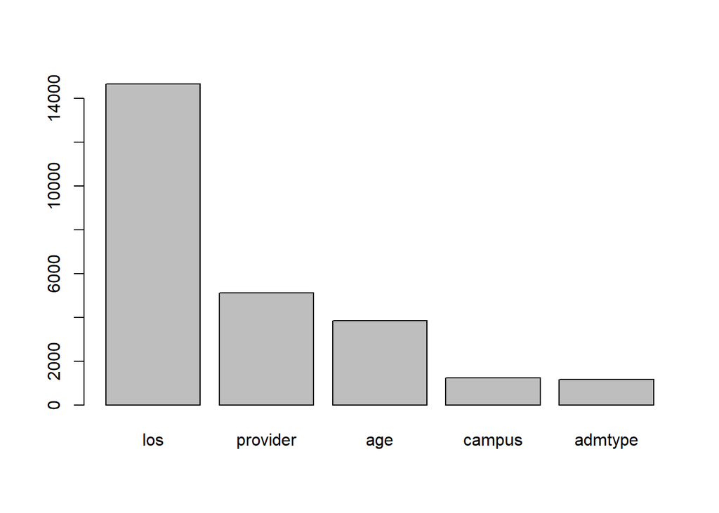

```r
barplot(tree_model$variable.importance)
```

3. Using caret for this question. Set `Training Control` to be: Use Cross-Validation of 5 folds across all models. Train & tune at least 2 different models (i.e. two different values for `method=` in the train function of caret). Plot the hyper-parameter tuning plots for each model.

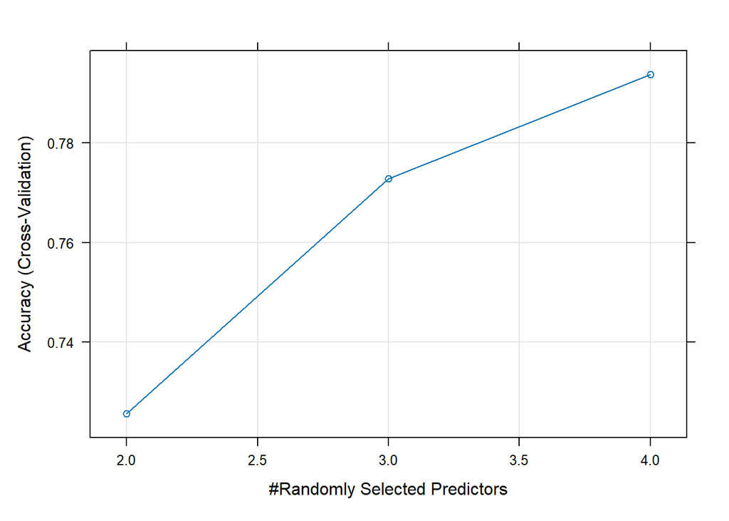

```r
library(caret)
set.seed(100)
splitIndex <- createDataPartition(df$target, p = .1,
                                  list = FALSE)
df_train <- df[ splitIndex,]
df_test <- df[-splitIndex,]

trControl = trainControl(method = "cv",
                         number = 5)
tuneGrid = expand.grid(mtry=2:4)

rf <- train(target~., data=df_train,
                    method = "rf",
                    ntree = 10,
                    trControl = trControl,
                    tuneGrid = tuneGrid)

plot(rf)
```

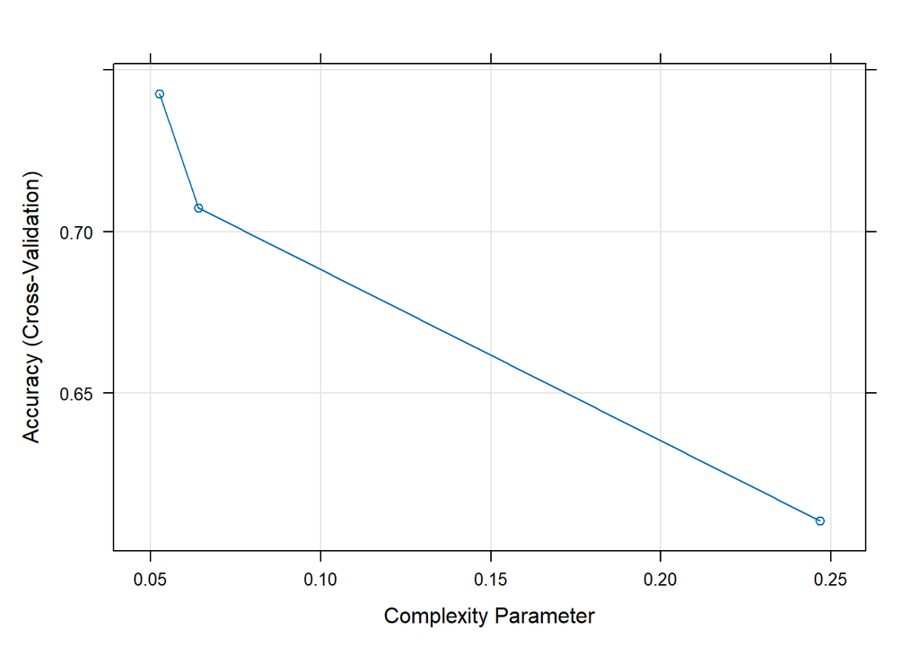

```r
library(caret)
set.seed(100)
splitIndex <- createDataPartition(df$target, p = .1,
                                  list = FALSE)
df_train <- df[ splitIndex,]
df_test <- df[-splitIndex,]

trControl = trainControl(method = "cv",
                         number = 5)
#tuneGrid = expand.grid(mtry=2:4)

rpart <- train(target~., data=df_train,
                    method = "rpart",
                    trControl = trControl)
                   # tuneGrid = tuneGrid)

plot(rpart)
```

4. Plot the comparison of the models in 3.

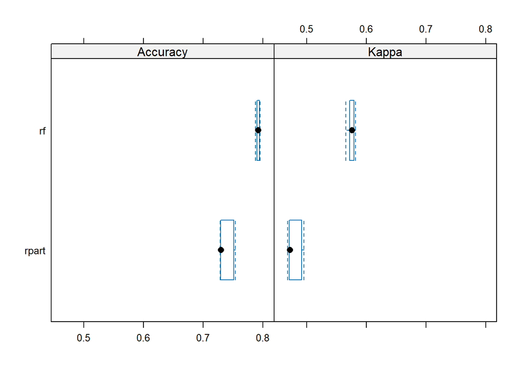

```r
trControl = trainControl(method = "cv",
                         number = 5)
rf <- train(target~., data=df_train,
                                method = "rf",
                                ntree=10,
                                trControl = trControl)
rpart <- train(target~., data=df_train,
                    method = "rpart",
                                trControl = trControl)

results <- resamples(list('rf' = rf,
                          'rpart' = rpart
                          ))
bwplot(results)
```

5. What is your final selection for the model? Test the accuracy of your final model on the test data.

```r
pred <- predict(rf, df_test)
#Evaluate the predictions
cm <- confusionMatrix(data = pred, reference = factor(df_test$target), positive = "high")
cm$overall[1]
```

```
##  Accuracy
## 0.7944006
```

6. Create another `target` variable (binary), decide the input variables and redo 1 to 5.

```r
setwd("C:/Users/student/Downloads")
df <- read_csv('421midterm.csv')
df$sex <- case_when(
  df$sex == 2 ~ 'Female',
  TRUE ~ 'Male')

df$raceethn = as.character(df$raceethn)
df$provider = as.character(df$provider)
df$admtype = as.character(df$admtype)
#df <- read_sas('hdd0318cy.sas7bdat')
#n = nrow(df)
#n
#df = df[sample(1:n, 1000), ]


df$ages <- case_when(
  df$age < 50 ~ 'low',
  TRUE ~ 'high')



df <- df %>% rename(target=ages)
df <- df %>% select(sex, provider, moa, mod, admtype, campus, los, target, tot, drg, asource)
df = drop_na(df)
df <- df %>%
  mutate(target = as.factor(target),
         asource = as.factor(asource),
         provider = as.factor(provider),
         sex = as.factor(sex),
         admtype = as.factor(admtype),
         campus = as.factor(campus)
         )

#install.packages("caret")
library(caret)
set.seed(100)
splitIndex <- createDataPartition(df$target, p = .1,
                                  list = FALSE)
df_train <- df[ splitIndex,]
df_test <- df[-splitIndex,]
```

[figure not shown]

```r
library(rpart) #load the rpart package
# Create a tree
tree_model <- rpart(target ~ ., data = df_train,
                 control = rpart.control(maxdepth = 3))
library(rattle)
fancyRpartPlot(tree_model)
```

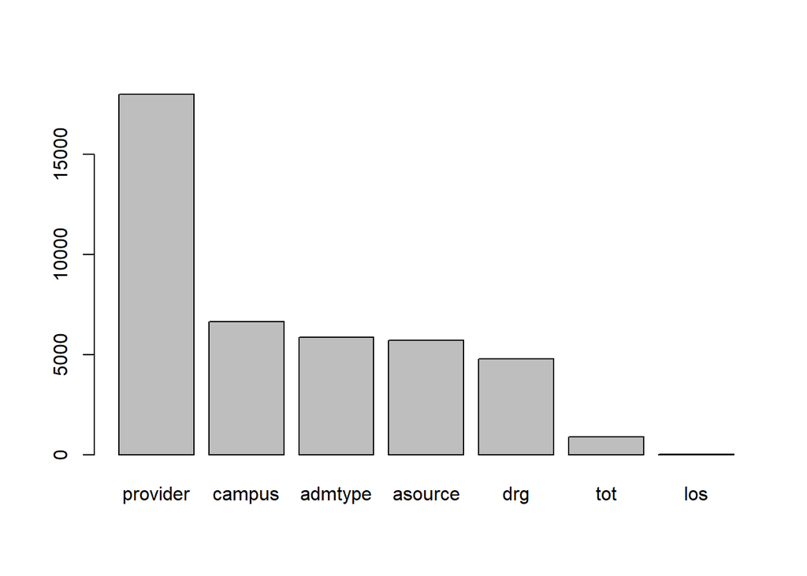

```r
barplot(tree_model$variable.importance)
```

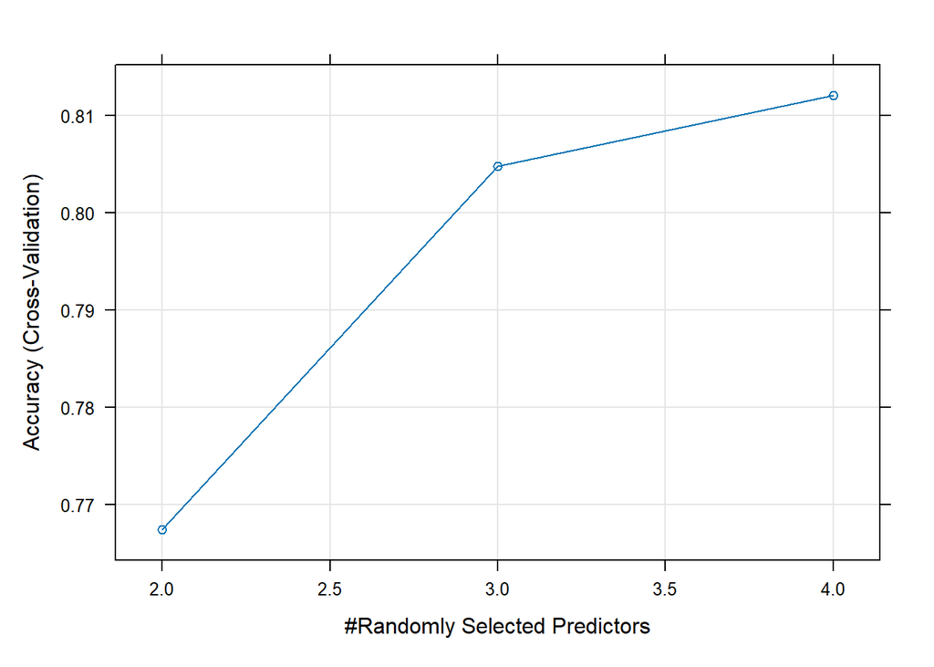

```r
library(caret)
set.seed(100)
# Handle missing values
splitIndex <- createDataPartition(df$target, p = .1,
                                  list = FALSE)
df_train <- df[ splitIndex,]
df_test <- df[-splitIndex,]

trControl = trainControl(method = "cv",
                         number = 5)
tuneGrid = expand.grid(mtry=2:4)

rf <- train(target~., data=df_train,
                    method = "rf",
                    ntree=10,
                    trControl = trControl,
                    tuneGrid = tuneGrid)

plot(rf)
```

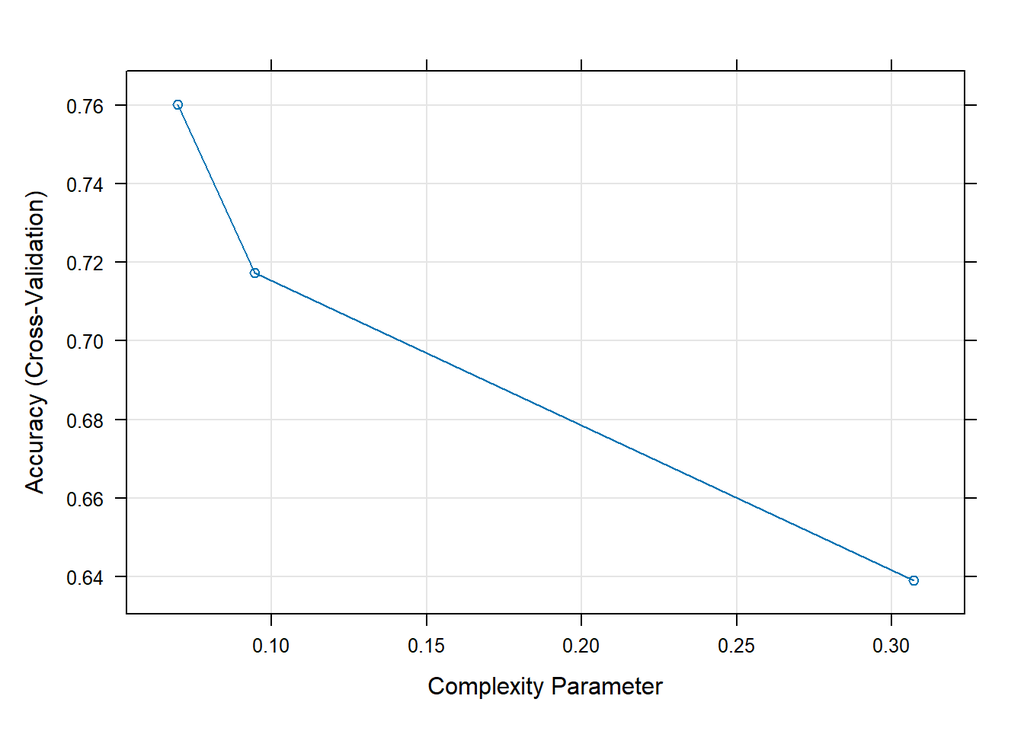

```r
library(caret)
set.seed(100)
splitIndex <- createDataPartition(df$target, p = .1,
                                  list = FALSE)
df_train <- df[ splitIndex,]
df_test <- df[-splitIndex,]

trControl = trainControl(method = "cv",
                         number = 5)
#tuneGrid = expand.grid(mtry=2:4)

rpart <- train(target~., data=df_train,
                    method = "rpart",
                    trControl = trControl)
                    #tuneGrid = tuneGrid)

plot(rpart)
```

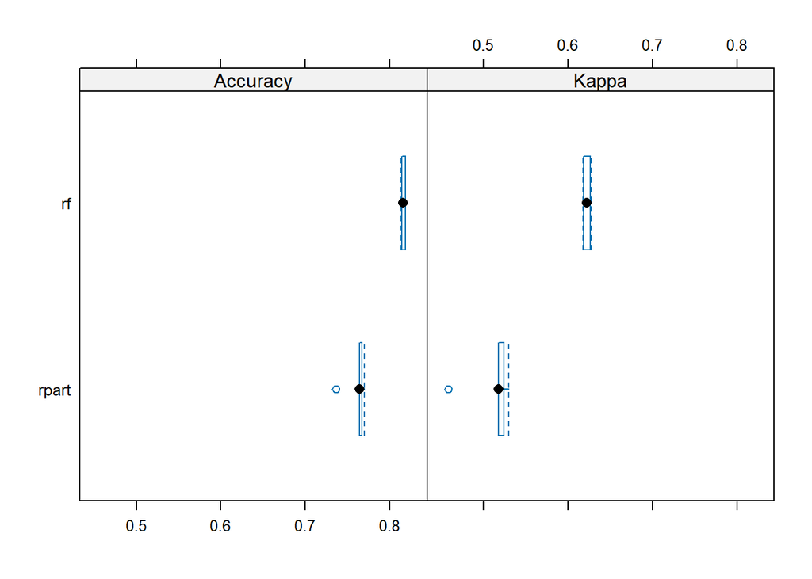

```r
trControl = trainControl(method = "cv",
                         number = 5)
rpart <- train(target~., data=df_train,
                                method = "rpart",
                                trControl = trControl)
rf <- train(target~., data=df_train,
                    method = "rf",
                    ntree=10,
                                trControl = trControl)

results <- resamples(list('rpart' = rpart,
                          'rf' = rf
                          ))
bwplot(results)
```

```r
pred <- predict(rf, df_test)
#Evaluate the predictions
cm <- confusionMatrix(data = pred, reference = factor(df_test$target), positive = "high")
cm$overall[1]
```

```
##  Accuracy
## 0.8175469
```

7. Write a paragraph to summarize the section and give your comments on the results.

For the mode comparisons, the rf had a significantly higher accuracy score than the rpart model and was able to get a 79% accuracy score.